# Calculating Non-Dementia Mortality

Sigal Maya

Updated 07-29-2026

The model utilizes the risk ratio for mortality to evaluate the increased risk for death among those with dementia. However, using the risk ratio in conjunction with all-cause mortality inflates overall mortality in the model. We thus estimated the non-dementia-related mortality rate (i.e, mortality among those without the risk factor) by removing dementia-related deaths from all-cause deaths at each age and sex. Death counts and populations were obtained from the CDC WONDER database.

Two features of the source data shape the approach:

Because rates cannot be computed above age 84, all-cause mortality must be extrapolated over that range. We first inspected the crude rates by age to confirm that mortality grows exponentially with age, which is what motivates the log-linear extrapolation below:

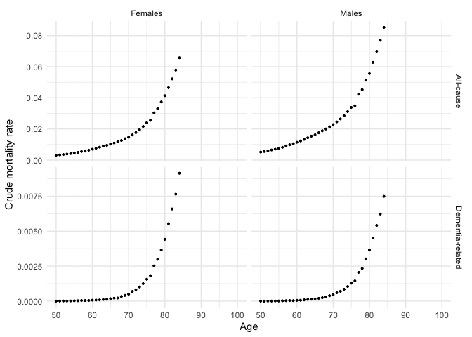

We used a log-transformed linear model with age as the predictor variable to extrapolate all-cause mortality rates up to age 100 (the maximum age allowed in the microsimulation), fitting the two sexes separately. Initial models using all data points resulted in predictions that were not smooth, so the fit uses observed rates from ages 76–84 only. The `predict()` function was applied to every age and the exponentiated predictions were used to fill the missing rates, leaving observed rates untouched. Data were visually inspected to confirm a smooth and uninterrupted exponential increase in all-cause mortality rate with age.

This is the only extrapolation the pipeline depends on, and it is its weakest step: nine observed points projected sixteen years. `data/mortality/table_prob_die_next_year.csv` carries an independent $q(x)$ for ages 85–100 and can be used to sanity-check the shape. Sourcing single-year populations for ages 85–100 from Census or SSA would remove the need for this step entirely.

On a log scale the observed rates should fall on a straight line (that is what makes the log-linear fit appropriate) and the extrapolated points should continue it without a visible step at the 84/85 join:

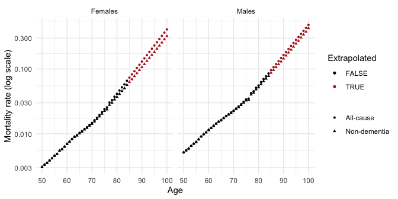

Non-dementia mortality then follows from the observed dementia share of deaths:

$$\text{rate}_\text{non-dementia}(a) \;=\;
\text{rate}_\text{all-cause}(a) \times \left(1 -
\frac{d_\text{dementia}(a)}{d_\text{all-cause}(a)}\right)$$

Wherever both rates are observed this is algebraically identical to subtracting one from the other, since $(d_\text{all} - d_\text{dem}) / \text{pop} = (d_\text{all} / \text{pop}) \times (1 - d_\text{dem} / d_\text{all})$. Its advantage is above age 84, where the share is still observed even though neither rate is, because the share is computed from counts and needs no denominator.

Finally, we converted rates to probabilities using the equation $\text{probability} = 1 - e^{-\text{rate}}$.

## Output

The checks below verify the invariant.

```
[1] 102
[1]  50 100
[1] 64
[1] FALSE
NULL
NULL
numeric(0)
[1] TRUE
[1] TRUE
```